# Homework #03: The Joy of Probability

due February 24 11:59 PM

Dav King

2/17/2022

# Load Packages and Data

```r
library(tidyverse)
library(fivethirtyeight)
library(viridis)
library(knitr)
```

# Exercise 1

```r
bob_ross %>%
  count(tree) %>%
  mutate(tree_prob = n/sum(n))
```

| tree | n | tree_prob |
| --- | --- | --- |
| 0 | 42 | 0.1042184 |
| 1 | 361 | 0.8957816 |

There are 403 episodes, in 361 of which a tree was painted. The probability that a randomly selected episode featured a tree is 0.896.

# Exercise 2

```r
bob_ross %>%
  filter(guest == 1) %>%
  summarize(prob_steve = mean(steve_ross))
```

| prob_steve |
| --- |
| 0.5 |

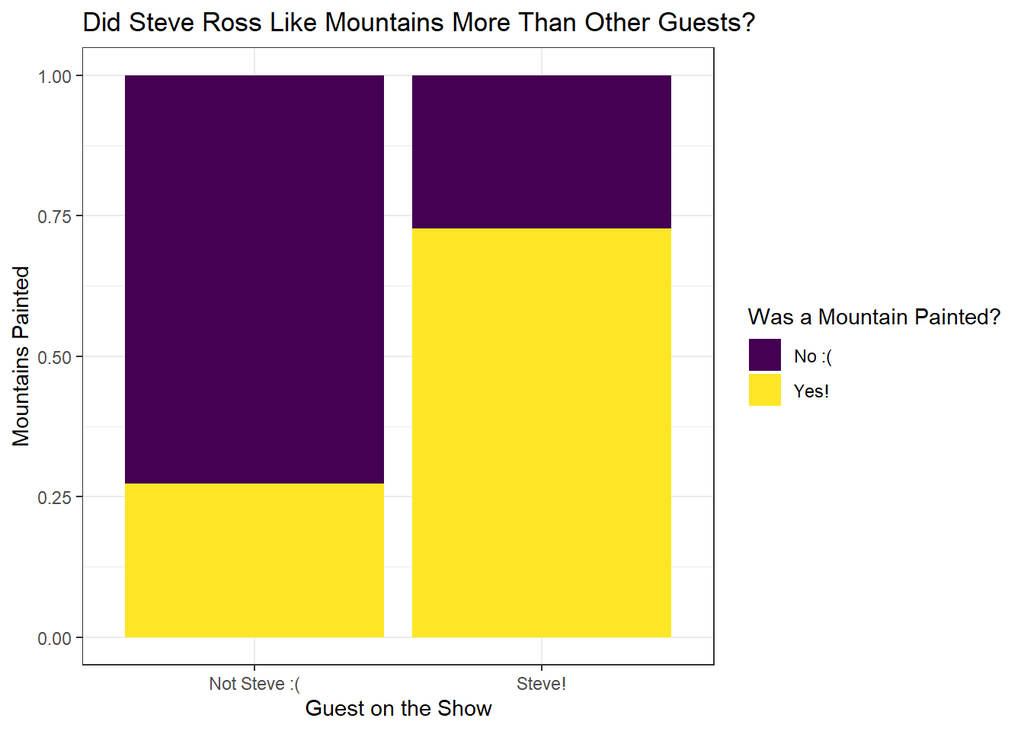

```r
bob_ross %>%
  filter(guest == 1) %>%
  mutate(steve = if_else(steve_ross == 1, "Steve!", "Not Steve :(")) %>%
  mutate(mount = if_else(mountain == 1, "Yes!", "No :(")) %>%
  ggplot(aes(x = steve, fill = factor(mount))) +
  geom_bar(position = "fill") +
  labs(title = "Did Steve Ross Like Mountains More Than Other Guests?",
       x = "Guest on the Show", y = "Mountains Painted",
       fill = "Was a Mountain Painted?") +
  scale_fill_viridis(discrete = T) +
  theme_bw()
```

# Exercise 3

```r
ross_paintings <- bob_ross %>%
  filter(guest == 0)
```

# Exercise 4

```r
ross_paintings %>%
  filter(cirrus == 1 & cumulus == 1) %>%
  select(episode, cirrus, cumulus)
```

| episode | cirrus | cumulus |
| --- | --- | --- |
| S02E09 | 1 | 1 |

They are not disjoint - though there is only one instance in which the two clouds were painted together, there was still such an instance; thus, they cannot be mutually exclusive.

# Exercise 5

```r
M <- ross_paintings %>%
  filter(cabin == 1) %>%
  count(cabin)

X <- ross_paintings %>%
  filter(cabin == 1) %>%
  filter(lake == 1) %>%
  count(lake)

set.seed(2182022) # don't change the seed
num_lakes = rbinom(100000, M$n, prob = 0.5)
cabin_lakes = data.frame(num_lakes)

cabin_lakes %>%
  mutate(prob_lakes = if_else(num_lakes <= X$n, 1, 0)) %>%
  summarize(answer = mean(prob_lakes))
```

| answer |
| --- |
| 0.00999 |

The probability that Bob Ross painted `X` or fewer lakes, given that he flipped a fair coin to decide whether or not to paint one every time, is 0.00999.

# Exercise 6

```r
A <- ross_paintings %>%
  summarize(prob_mountain = mean(mountain), prob_river = mean(river))

B <- ross_paintings %>%
  filter(river == 1) %>%
  summarize(mountain_given_river = mean(mountain))

(B$mountain_given_river * A$prob_river)/A$prob_mountain
```

```
## [1] 0.3221477
```

```r
A$prob_mountain
```

```
## [1] 0.3910761
```

```r
B$mountain_given_river
```

```
## [1] 0.3870968
```

Bob Ross does not paint mountains independent of whether or not he paints rivers. The probability that he paints a mountain is 0.391. If they were independent, we would expect the probability of a mountain to be painted given that a river was painted to also be 0.391. However, in paintings where a river was painted, this probability is 0.387. Though this difference is slight, it is still present; thus, we can safely say that these two events are not independent.

# Exercise 7

Does the relative prevalence of different types of water in this show’s paintings vary according to the presence of guests on the show and/or an episode’s place within a season?

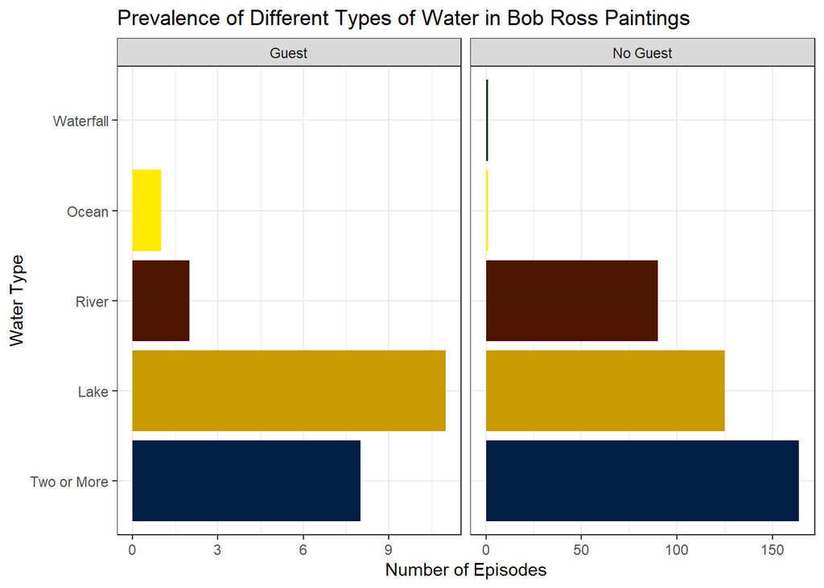

```r
ross3 <- bob_ross %>%
  mutate(water_type = case_when(
    waves == 1 & ocean == 0 & waterfall == 0 & river == 0 &
      lake == 0 ~ "Waves",
    waves == 0 & ocean == 1 & waterfall == 0 & river == 0 &
      lake == 0 ~ "Ocean",
    waves == 0 & ocean == 0 & waterfall == 1 & river == 0 &
      lake == 0 ~ "Waterfall",
    waves == 0 & ocean == 0 & waterfall == 0 & river == 1 &
      lake == 0 ~ "River",
    waves == 0 & ocean == 0 & waterfall == 0 & river == 0 &
      lake == 1 ~ "Lake",
    T ~ "Two or More"
  )) %>%
  mutate(nom_guest = if_else(guest == 0, "No Guest", "Guest"))

ross_palette <- c("River" = "#4E1500", "Ocean" = "#FFEC00",
                  "Waterfall" = "#0A3410", "Two or More" = "#021E44",
                  "Lake" = "#C79B00")

ross3 %>%
  group_by(water_type, nom_guest) %>%
  summarize(water_presence = n()) %>%
  ggplot(aes(x = reorder(water_type, -water_presence),
                  y = water_presence, fill = water_type)) +
  geom_col() +
  labs(title = "Prevalence of Different Types of Water in Bob Ross Paintings",
       x = "Water Type", y = "Number of Episodes") +
  theme_bw() +
  coord_flip() +
  scale_fill_manual(values = ross_palette) +
  guides(fill = "none") +
  facet_wrap(~ nom_guest, scales = "free_x")
```

```r
pop <- count(ross3)

pWaterfall <- ross3 %>%
  filter(water_type == "Waterfall") %>%
  count(water_type) %>%
  mutate(p = n/pop)

pOcean <- ross3 %>%
  filter(water_type == "Ocean") %>%
  count(water_type) %>%
  mutate(p = n/pop)

pRiver <- ross3 %>%
  filter(water_type == "River") %>%
  count(water_type) %>%
  mutate(p = n/pop)

pLake <- ross3 %>%
  filter(water_type == "Lake") %>%
  count(water_type) %>%
  mutate(p = n/pop)

pTwo <- ross3 %>%
  filter(water_type == "Two or More") %>%
  count(water_type) %>%
  mutate(p = n/pop)

marginal_p_water <- c(pLake$p$n, pOcean$p$n, pRiver$p$n,
                      pTwo$p$n, pWaterfall$p$n)

ross4 <- ross3 %>%
  count(water_type, nom_guest) %>%
  pivot_wider(names_from = nom_guest, values_from = n)

ross4$marginal_p_water <- marginal_p_water
kable(ross4)
```

| water_type | Guest | No Guest | marginal_p_water |
| --- | --- | --- | --- |
| Lake | 11 | 125 | 0.3374690 |
| Ocean | 1 | 1 | 0.0049628 |
| River | 2 | 90 | 0.2282878 |
| Two or More | 8 | 164 | 0.4267990 |
| Waterfall | NA | 1 | 0.0024814 |

This graph and table suggest that there is likely a difference in the prevalence of each type of water depending on the presence of a guest, but does not necessarily statistically confirm it - this, however, will.

```r
p_given_guest <- ross3 %>%
  filter(nom_guest == "Guest") %>%
  count(water_type) %>%
  mutate(p = n/sum(n))

p_given_no_guest <- ross3 %>%
  filter(nom_guest == "No Guest") %>%
  count(water_type) %>%
  mutate(p = n/sum(n))

#Eventually I will teach myself how to write functions
p_guest_ocean <- filter(p_given_guest, water_type == "Ocean")
p_guest_river <- filter(p_given_guest, water_type == "River")
p_guest_lake <- filter(p_given_guest, water_type == "Lake")
p_guest_two <- filter(p_given_guest, water_type == "Two or More")

guest_probs <- c("X", p_guest_ocean$p, p_guest_river$p,
                 p_guest_lake$p, p_guest_two$p)

p_no_guest_wf <- filter(p_given_no_guest, water_type == "Waterfall")
p_no_guest_ocean <- filter(p_given_no_guest, water_type == "Ocean")
p_no_guest_river <- filter(p_given_no_guest, water_type == "River")
p_no_guest_lake <- filter(p_given_no_guest, water_type == "Lake")
p_no_guest_two <- filter(p_given_no_guest, water_type == "Two or More")

no_guest_probs <- c(p_no_guest_wf$p, p_no_guest_ocean$p, p_no_guest_river$p,
                    p_no_guest_lake$p, p_no_guest_two$p)

A <- "X"
B <- p_guest_ocean$p == p_no_guest_ocean$p
C <- p_guest_river$p == p_no_guest_river$p
D <- p_guest_lake$p == p_no_guest_lake$p
E <- p_guest_two$p == p_no_guest_two$p

across_conditions <- c(A, B, C, D, E)

A1 <- "X"
B1 <- p_guest_ocean$p == pOcean$p$n
C1 <- p_guest_river$p == pRiver$p$n
D1 <- p_guest_lake$p == pLake$p$n
E1 <- p_guest_two$p == pTwo$p$n

guest_vs_baseline <- c(A1, B1, C1, D1, E1)

A2 <- p_no_guest_wf$p == pWaterfall$p$n
B2 <- p_no_guest_ocean$p == pOcean$p$n
C2 <- p_no_guest_river$p == pRiver$p$n
D2 <- p_no_guest_lake$p == pLake$p$n
E2 <- p_no_guest_two$p == pTwo$p$n

no_guest_vs_baseline <- c(A2, B2, C2, D2, E2)

cProb_table <- data.frame(ross4$water_type, guest_probs, no_guest_probs,
                    guest_vs_baseline, no_guest_vs_baseline, across_conditions)

kable(cProb_table)
```

| ross4.water_type | guest_probs | no_guest_probs | guest_vs_baseline | no_guest_vs_baseline | across_conditions |
| --- | --- | --- | --- | --- | --- |
| Lake | X | 0.0026247 | X | FALSE | X |
| Ocean | 0.0454545454545455 | 0.0026247 | FALSE | FALSE | FALSE |
| River | 0.0909090909090909 | 0.2362205 | FALSE | FALSE | FALSE |
| Two or More | 0.5 | 0.3280840 | FALSE | FALSE | FALSE |
| Waterfall | 0.363636363636364 | 0.4304462 | FALSE | FALSE | FALSE |

As we can see, in none of these conditions (for any type of water, guest or no guest as compared both to the total dataset and to each other) are the marginal probabilities equal to one another; thus, these two events are not independent of one another.

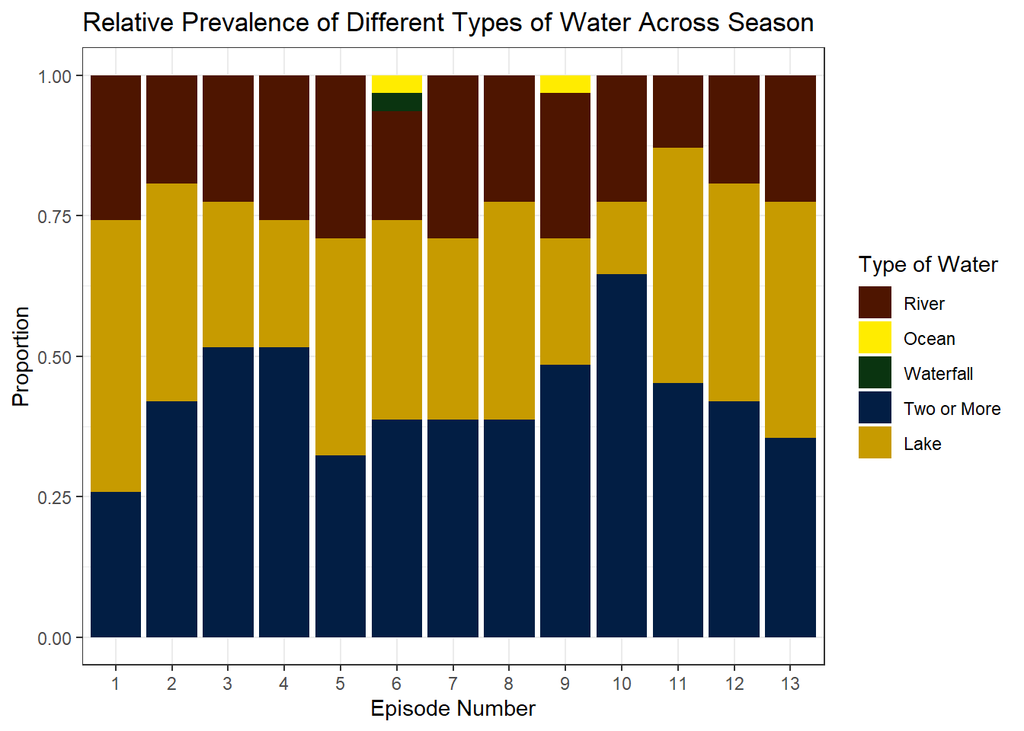

```r
ross3 %>%
  group_by(water_type, nom_guest) %>%
  mutate(water_presence = n()) %>%
  ggplot(aes(x = factor(episode_num),
             fill = reorder(water_type, water_presence))) +
  geom_bar(position = "fill") +
  labs(title = "Relative Prevalence of Different Types of Water Across Season",
       x = "Episode Number", y = "Proportion", fill = "Type of Water") +
  theme_bw() +
  scale_fill_manual(values = ross_palette)
```

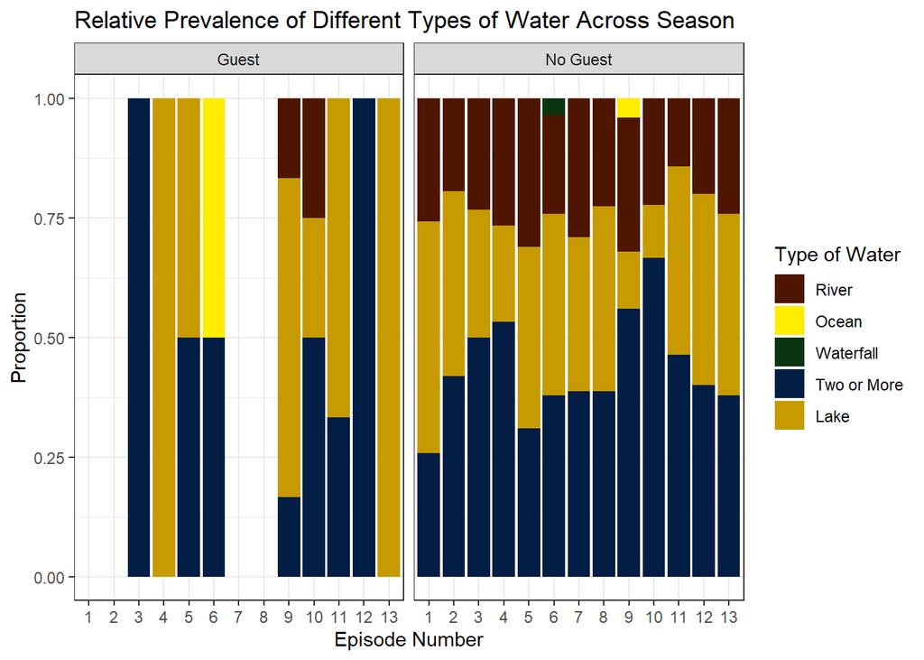

```r
ross3 %>%
  group_by(water_type, nom_guest) %>%
  mutate(water_presence = n()) %>%
  ggplot(aes(x = factor(episode_num),
             fill = reorder(water_type, water_presence))) +
  geom_bar(position = "fill") +
  labs(title = "Relative Prevalence of Different Types of Water Across Season",
       x = "Episode Number", y = "Proportion", fill = "Type of Water") +
  theme_bw() +
  scale_fill_manual(values = ross_palette) +
  facet_wrap(~ nom_guest)
```

These once again suggest both that A) there is a difference in the relative prevalence of each type of water across the season and B) that this varies according to whether or not there was a guest on the show; but again, let us turn to statistics:

```r
timeline <- ross3 %>%
  #For simplicity's sake, we will group the episodes into three chunks
  mutate(chunked = case_when(
    episode_num <= 4 ~ "Early",
    episode_num <= 8 ~ "Middle",
    T ~ "Late"
  )) %>%
  mutate(chunked = factor(chunked, levels = c("Early", "Middle", "Late"),
                          ordered = T)) %>%
  arrange(chunked)

early_prob <- timeline %>%
  filter(chunked == "Early") %>%
  count(water_type) %>%
  mutate(p = n/sum(n))

middle_prob <- timeline %>%
  filter(chunked == "Middle") %>%
  count(water_type) %>%
  mutate(p = n/sum(n))

late_prob <- timeline %>%
  filter(chunked == "Late") %>%
  count(water_type) %>%
  mutate(p = n/sum(n))

early_prob
```

| water_type | n | p |
| --- | --- | --- |
| Lake | 42 | 0.3387097 |
| River | 29 | 0.2338710 |
| Two or More | 53 | 0.4274194 |

```r
middle_prob
```

| water_type | n | p |
| --- | --- | --- |
| Lake | 45 | 0.362903226 |
| Ocean | 1 | 0.008064516 |
| River | 31 | 0.250000000 |
| Two or More | 46 | 0.370967742 |
| Waterfall | 1 | 0.008064516 |

```r
late_prob
```

| water_type | n | p |
| --- | --- | --- |
| Lake | 49 | 0.316129032 |
| Ocean | 1 | 0.006451613 |
| River | 32 | 0.206451613 |
| Two or More | 73 | 0.470967742 |

```r
#In the interest of time, I won't do the logic calculations - we can all see
#that none of those numbers are the same across groups
```

```r
early_guest <- timeline %>%
  filter(chunked == "Early" & guest == 1) %>%
  count(water_type) %>%
  mutate(p = n/sum(n))

middle_guest <- timeline %>%
  filter(chunked == "Middle" & guest == 1) %>%
  count(water_type) %>%
  mutate(p = n/sum(n))

late_guest <- timeline %>%
  filter(chunked == "Late" & guest == 1) %>%
  count(water_type) %>%
  mutate(p = n/sum(n))

early_no_guest <- timeline %>%
  filter(chunked == "Early" & guest == 0) %>%
  count(water_type) %>%
  mutate(p = n/sum(n))

middle_no_guest <- timeline %>%
  filter(chunked == "Middle" & guest == 0) %>%
  count(water_type) %>%
  mutate(p = n/sum(n))

late_no_guest <- timeline %>%
  filter(chunked == "Late" & guest == 0) %>%
  count(water_type) %>%
  mutate(p = n/sum(n))

early_prob
```

| water_type | n | p |
| --- | --- | --- |
| Lake | 42 | 0.3387097 |
| River | 29 | 0.2338710 |
| Two or More | 53 | 0.4274194 |

```r
early_guest
```

| water_type | n | p |
| --- | --- | --- |
| Lake | 1 | 0.5 |
| Two or More | 1 | 0.5 |

```r
early_no_guest
```

| water_type | n | p |
| --- | --- | --- |
| Lake | 41 | 0.3360656 |
| River | 29 | 0.2377049 |
| Two or More | 52 | 0.4262295 |

```r
middle_prob
```

| water_type | n | p |
| --- | --- | --- |
| Lake | 45 | 0.362903226 |
| Ocean | 1 | 0.008064516 |
| River | 31 | 0.250000000 |
| Two or More | 46 | 0.370967742 |
| Waterfall | 1 | 0.008064516 |

```r
middle_guest
```

| water_type | n | p |
| --- | --- | --- |
| Lake | 1 | 0.25 |
| Ocean | 1 | 0.25 |
| Two or More | 2 | 0.50 |

```r
middle_no_guest
```

| water_type | n | p |
| --- | --- | --- |
| Lake | 44 | 0.366666667 |
| River | 31 | 0.258333333 |
| Two or More | 44 | 0.366666667 |
| Waterfall | 1 | 0.008333333 |

```r
late_prob
```

| water_type | n | p |
| --- | --- | --- |
| Lake | 49 | 0.316129032 |
| Ocean | 1 | 0.006451613 |
| River | 32 | 0.206451613 |
| Two or More | 73 | 0.470967742 |

```r
late_guest
```

| water_type | n | p |
| --- | --- | --- |
| Lake | 9 | 0.5625 |
| River | 2 | 0.1250 |
| Two or More | 5 | 0.3125 |

```r
late_no_guest
```

| water_type | n | p |
| --- | --- | --- |
| Lake | 40 | 0.287769784 |
| Ocean | 1 | 0.007194245 |
| River | 30 | 0.215827338 |
| Two or More | 68 | 0.489208633 |

The only value held in common (and thus even remotely plausible to be independent) anywhere in this calculation is a 50% chance of two or more types of water in both the early and middle chunks of the season on shows that had guests - clearly, these values cannot be considered independent of one another.